# Applied Statistics: Final Assignment

## 5.1 State

As our data is largely concentrated around employees working in the US, we want to investigate further into the differences of salary distribution within the US demographically. To clean the state variable, we only chose entries that have a frequency higher than 10, which leaves us with 50 states and District of Columbia. During this process, we only removed 100 entries in a total of 21562 entries, therefore we can assume that we did not lose any generality during the cleaning.

```r
# Remove all observations that has NA state, i.e. observations out of US
ask_a_manager_2021_state <- ask_a_manager_2021[!(is.na(ask_a_manager_2021$state)),]


# Only include observations with entries higher than 10
state_list <- ask_a_manager_2021_state %>%
  count(state, sort=TRUE) %>%
  filter(n >= 10) %>%
  select(state) %>%
  pull()

ask_a_manager_2021_state <- ask_a_manager_2021[ask_a_manager_2021$state %in% state_list,]
```

```r
ask_a_manager_2021_state_salary <- ask_a_manager_2021_state %>%
  group_by(state) %>%
  summarise(mean_salary = mean(USD_salary))

ask_a_manager_2021_state_salary$state <- tolower(ask_a_manager_2021_state_salary$state)

# US Map data
MainStates <- map_data("state")
MainStates <- MainStates %>%
  rename(state = region)

ask_a_manager_2021_state_salary <- ask_a_manager_2021_state_salary %>%
  inner_join(MainStates, by="state")
```

The map below shows the mean salary for each states in the Mainland US.

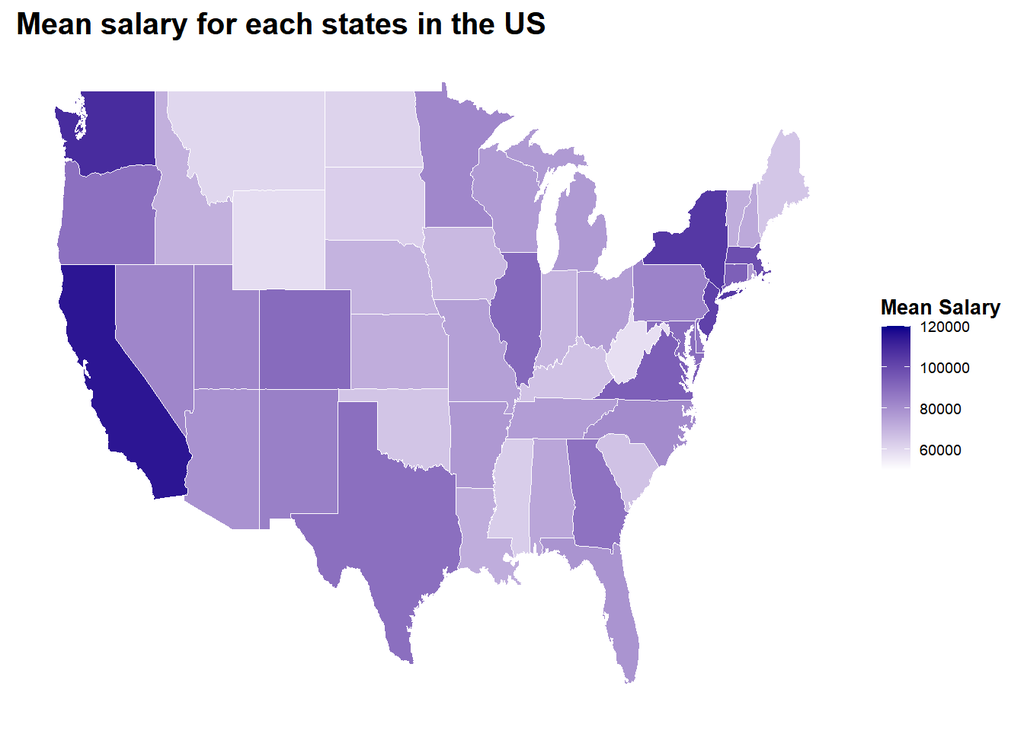

```r
ggplot(ask_a_manager_2021_state_salary) +
  geom_polygon(aes(x = long, y = lat, group = group, fill = mean_salary),
               color = "white", size = 0.2) +
  scale_fill_continuous(name="Mean Salary",
            low = "white", high = "darkblue", limits = c(50000,120000),
            na.value = "grey50") +
  theme_bw() +
  theme(axis.line=element_blank(),
        axis.text.x=element_blank(),
        axis.text.y=element_blank(),
        axis.ticks=element_blank(),
        axis.title.x=element_blank(),
        axis.title.y=element_blank(),
        legend.key.size = unit(5, 'mm'),
        legend.title = element_text(size = 10, face = "bold"),
        legend.text = element_text(size = 7),
        panel.background=element_blank(),
        panel.border=element_blank(),
        panel.grid.major=element_blank(),
        panel.grid.minor=element_blank(),
        plot.background=element_blank(),
        plot.title = element_text(size = 15, face = "bold")) +
  labs(title = "Mean salary for each states in the US") +
  NULL
```

We can observe from the map that coastal states have a much darker color than the inland states. We will then do a t-test to see if the difference in salary between coastal states and inland states.

```r
# Identify costal states (Sourced from Wikipedia)
coastal_states <- c("alaska","california","hawaii","oregon","washington", "maine", "new hampshire", "massachusetts", "rhode island", "connecticut", "new york", "new jersey", "delaware", "maryland", "virginia", "north carolina", "south carolina", "georgia", "florida")

ask_a_manager_2021_state$state <- tolower(ask_a_manager_2021_state$state)

ask_a_manager_2021_state <- ask_a_manager_2021_state %>%
  mutate(coastal_state = ifelse(state %in% coastal_states, "Yes", "No"))

# T-test to test for the significance of the differences
t.test(USD_salary ~ coastal_state, data = ask_a_manager_2021_state)
```

```
##
##  Welch Two Sample t-test
##
## data:  USD_salary by coastal_state
## t = -17.267, df = 20662, p-value < 2.2e-16
## alternative hypothesis: true difference in means between group No and group Yes is not equal to 0
## 95 percent confidence interval:
##  -18219.89 -14505.02
## sample estimates:
##  mean in group No mean in group Yes
##          83120.42          99482.88
```

In this t-test, we have a t-statistic of up to 17.267 and a p-value close to 0. We are able to conclude that there is a difference in the salary between inland and coastal states. Demographically, this makes sense as coastal states tends to be more developed due to access to ports for international trading. This will lead to further economic development and hence the higher pay in these regions.

```r
# in USA, the difference of salary between bachelor and master degree
table(ask_a_manager_2021_industry$country_code)
```

```
##
##   AFG   ARE   ARG   AUS   AUT   BEL   BGD   BGR   BMU   BRA   CAN   CHE   CHL
##     1     2     1   335    15    26     1     2     2     3  1437    31     1
##   CHN   COG   COL   CRI   CUB   CYM   DEU   DNK   ECU   ERI   ESP   EST   FIN
##     3     1     1     1     1     1   169     9     1     1    37     2    14
##   FRA   GBR   GHA   GRC   HKG   HRV   HUN   IMN   IND   IRL   ISR   ITA   JAM
##    55  1368     2     5     4     1     1     1     4   104     7    11     1
##   JEY   JOR   JPN   KEN   KHM   KOR   KWT   LKA   LTU   LUX   LVA   MAR   MEX
##     1     1    23     1     1     1     1     1     2     2     3     1     3
##   MLT   MYS   NGA   NLD   NOR   NZL   PAK   PHL   POL   PRI   PRT   QAT   ROU
##     1     2     1    69     3   111     3     2     2     4     5     1     4
##   RWA   SGP   SLE   SOM   SRB   SVK   SVN   SWE   THA   UGA   UKR   URY   USA
##     1     4     1     1     1     1     1    33     2     1     1     1 19891
##   VNM   ZAF   ZWE
##     2    16     1
```

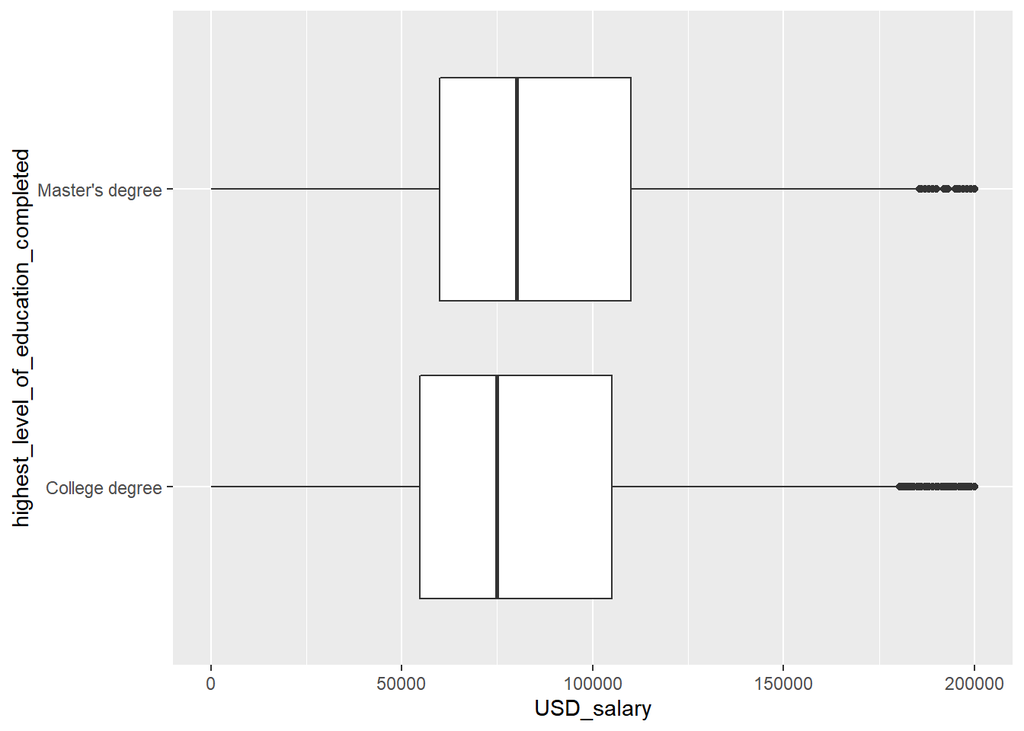

```r
#choose only college degree and master degree holder in USA
dif_degree<-ask_a_manager_2021_industry %>%
  filter(country_code =="USA") %>%
  filter(highest_level_of_education_completed=="College degree" | highest_level_of_education_completed=="Master's degree") %>%
  select(country_code,USD_salary,highest_level_of_education_completed)

#plot the boxplot of the differennt salary between this two degree holders
ggplot(dif_degree %>% select(USD_salary,highest_level_of_education_completed) %>% na.omit(), aes(x= USD_salary, y=highest_level_of_education_completed )) +
  geom_boxplot()+
  xlim(0,200000)
```

```r
#constructed confidence interval for bachelor degree holder in USA
confidence_interval_bachelor <- dif_degree %>%
  filter(highest_level_of_education_completed=="College degree" ) %>%
  select(USD_salary) %>%
  na.omit() %>%
  summarise(mean_salary_bachelor = mean(USD_salary),
            stder_salary_bachelor = sd(USD_salary)/ sqrt(n()),
            lower_bound_salary_bachelor_interval = mean_salary_bachelor - (1.96*stder_salary_bachelor),
            upper_bound_salary_bachelor_interval = mean_salary_bachelor + (1.96*stder_salary_bachelor))

#constructed confidence interval for master's degree holder in USA
confidence_interval_master <- dif_degree %>%
  filter(highest_level_of_education_completed=="Master's degree") %>%
  select(USD_salary) %>%
  na.omit() %>%
  summarise(mean_salary_master = mean(USD_salary),
            stder_salary_master = sd(USD_salary)/ sqrt(n()),
            lower_bound_salary_master_interval = mean_salary_master - (1.96*stder_salary_master),
            upper_bound_salary_master_interval = mean_salary_master + (1.96*stder_salary_master))
```

> We could use t.test to figure out the relationship between different degree and salary. Null hypothesis: there is no difference between different degree and salary

```r
#t.test of the relationship between different degree and salary
t.test(USD_salary ~ highest_level_of_education_completed, data = dif_degree)
```

```
##
##  Welch Two Sample t-test
##
## data:  USD_salary by highest_level_of_education_completed
## t = -4.6403, df = 9392.8, p-value = 3.527e-06
## alternative hypothesis: true difference in means between group College degree and group Master's degree is not equal to 0
## 95 percent confidence interval:
##  -8308.383 -3373.511
## sample estimates:
##  mean in group College degree mean in group Master's degree
##                      88263.22                      94104.17
```

> According to the t test, the t value equals to -4.6402, which is far away from -2, and the p value was far smaller than 0.05,so we can reject the hypothesis that there is no difference between bechelor degree salary and master’s degree salary in USA.

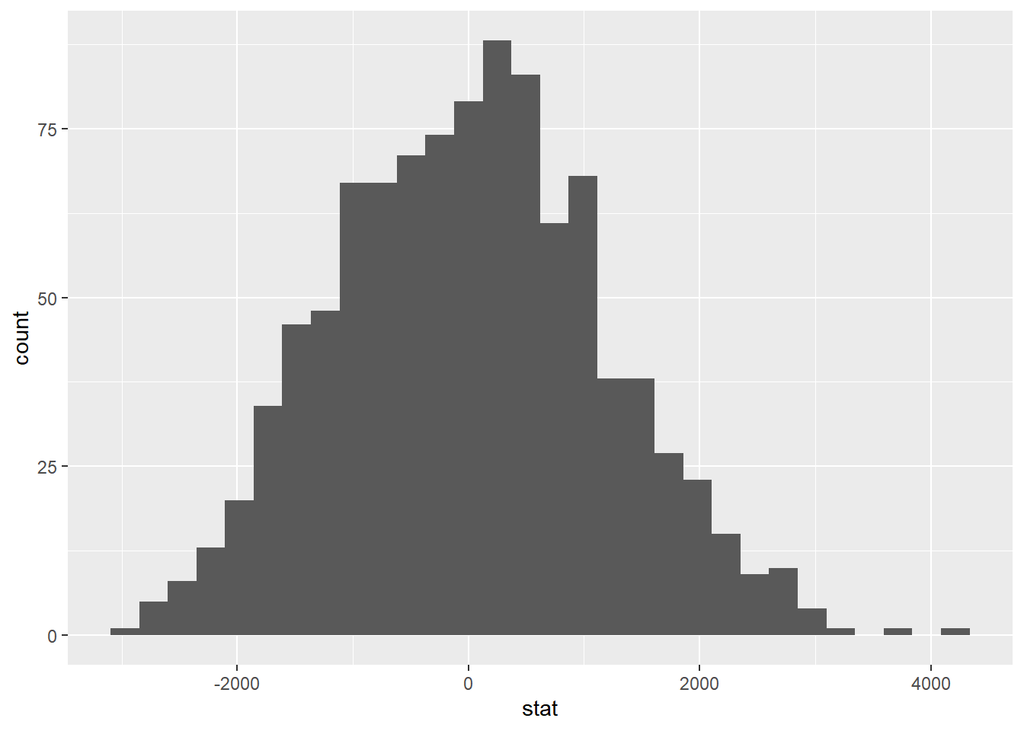

```r
obs_diff <- dif_degree %>%
  specify(USD_salary~ highest_level_of_education_completed) %>%
  calculate(stat = "diff in means", order = c("Master's degree", "College degree"))

null_dist <- dif_degree %>%
  # specify variables
  specify(USD_salary~ highest_level_of_education_completed) %>%

  # assume independence, i.e, there is no difference
  hypothesize(null = "independence") %>%

  # generate 1000 reps, of type "permute"
  generate(reps = 1000, type = "permute") %>%

  # calculate statistic of difference, namely "diff in means"
  calculate(stat = "diff in means", order = c("Master's degree", "College degree"))

ggplot(data = null_dist, aes(x = stat)) +
  geom_histogram(bins=30)
```

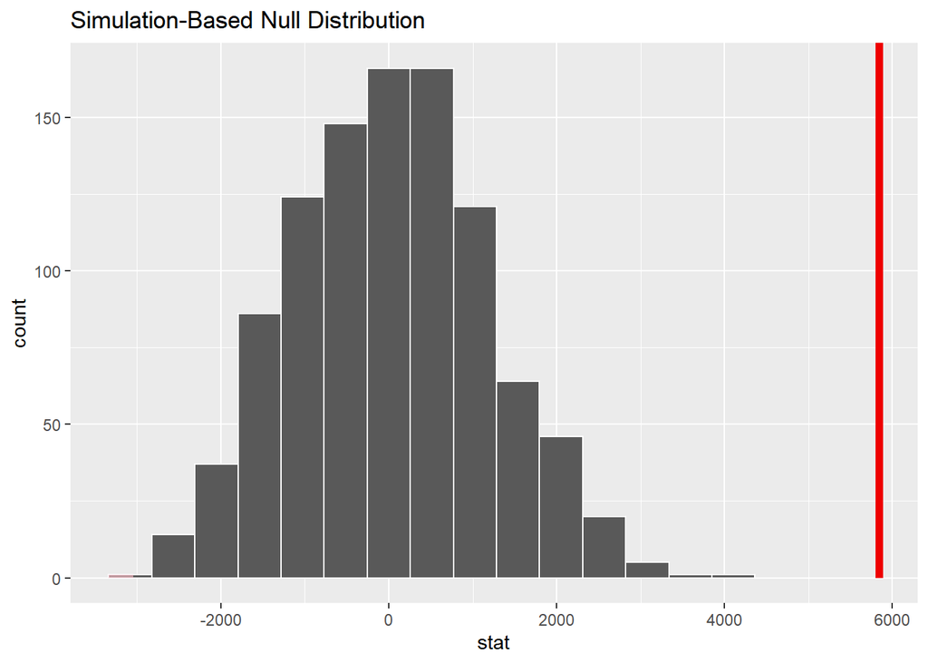

```r
null_dist %>% visualize() +
  shade_p_value(obs_stat = obs_diff, direction = "two-sided")
```

```r
null_dist %>%
  get_p_value(obs_stat = obs_diff, direction = "two_sided")
```

```
## # A tibble: 1 x 1
##   p_value
##     <dbl>
## 1       0
```

# 6 Model

## 6.1 Drop unnecessary columns

```r
df = subset(ask_a_manager_2021, select = -c(job_title, additional_context_on_job_title, additional_context_on_income, state, country) )
df = df[!(df$USD_salary == 0),]
```

```r
df_city <- df %>%
            count(city) %>%
            arrange(desc(n))
head(df_city, 50)
```

```
## # A tibble: 50 x 2
##    city              n
##    <chr>         <int>
##  1 Boston          796
##  2 Chicago         764
##  3 New York        745
##  4 Seattle         697
##  5 London          578
##  6 San Francisco   546
##  7 New York City   491
##  8 Los Angeles     484
##  9 Portland        449
## 10 Toronto         397
## # ... with 40 more rows
```

## 6.3 Create dummy variables for city column

```r
df$Boston <- ifelse(df$city == 'Boston', 1, 0)
df$Chicago <- ifelse(df$city == 'Chicago', 1, 0)
df$NewYork <- ifelse(df$city == 'New York', 1, 0)
df$Seattle <- ifelse(df$city == 'Seattle', 1, 0)
df$London <- ifelse(df$city == 'London', 1, 0)
df$SanFrancisco <- ifelse(df$city == 'San Francisco', 1, 0)
df$NewYorkCity <- ifelse(df$city == 'New York City', 1, 0)
df$LosAngeles <- ifelse(df$city == 'Los Angeles', 1, 0)
df$Portland <- ifelse(df$city == 'Portland', 1, 0)
df$Toronto <- ifelse(df$city == 'Toronto', 1, 0)
df$Minneapolis <- ifelse(df$city == 'Minneapolis', 1, 0)
df$Washington <- ifelse(df$city == 'Washington', 1, 0)
df$Austin <- ifelse(df$city == 'Austin', 1, 0)
df$Philadelphia <- ifelse(df$city == 'Philadelphia', 1, 0)
df$Atlanta <- ifelse(df$city == 'Atlanta', 1, 0)
df$Denver <- ifelse(df$city == 'Denver', 1, 0)
df$WashingtonDC <- ifelse(df$city == 'Washington, DC', 1, 0)
df$Houston <- ifelse(df$city == 'Houston', 1, 0)
df$Pittsburgh <- ifelse(df$city == 'Pittsburgh', 1, 0)
df$Vancouver <- ifelse(df$city == 'Vancouver', 1, 0)
df$Dallas <- ifelse(df$city == 'Dallas', 1, 0)
df$Madison <- ifelse(df$city == 'Madison', 1, 0)
df$Columbus <- ifelse(df$city == 'Columbus', 1, 0)
df$Baltimore <- ifelse(df$city == 'Baltimore', 1, 0)
df$Indianapolis <- ifelse(df$city == 'Indianapolis', 1, 0)
df$SanDiego <- ifelse(df$city == 'San Diego', 1, 0)
df$Raleigh <- ifelse(df$city == 'Raleigh', 1, 0)
df$Cleveland <- ifelse(df$city == 'Cleveland', 1, 0)
df$Phoenix <- ifelse(df$city == 'Phoenix', 1, 0)
df$Richmond <- ifelse(df$city == 'Richmond', 1, 0)
df$Ottawa <- ifelse(df$city == 'Ottawa', 1, 0)
df$Remote <- ifelse(df$city == 'Remote', 1, 0)
df$Arlington <- ifelse(df$city == 'Arlington', 1, 0)
df$Nashville <- ifelse(df$city == 'Nashville', 1, 0)
```

## 6.4 Create dummy variables for industry column

```r
df$industry_finance <- ifelse(df$industry == 'Accounting, Banking & Finance', 1, 0)
df$industry_agriculture <- ifelse(df$industry == 'Agriculture or Forestry', 1, 0)
df$industry_art <- ifelse(df$industry == 'Art & Design', 1, 0)
df$industry_business <- ifelse(df$industry == 'Business or Consulting', 1, 0)
df$industry_tech <- ifelse(df$industry == 'Computing or Tech', 1, 0)
df$industry_higher_education <- ifelse(df$industry == 'Education (Higher Education)', 1, 0)
df$industry_primary_education <- ifelse(df$industry == 'Education (Primary/Secondary)', 1, 0)
df$industry_engineering <-   ifelse(df$industry == 'Engineering or Manufacturing', 1, 0)
df$industry_entertainment <- ifelse(df$industry == 'Entertainment', 1, 0)
df$industry_government <- ifelse(df$industry == 'Government and Public Administration', 1, 0)
df$industry_health <- ifelse(df$industry == 'Health care', 1, 0)
df$industry_events <- ifelse(df$industry == 'Hospitality & Events', 1, 0)
df$industry_insurance <- ifelse(df$industry == 'Insurance', 1, 0)
df$industry_law <- ifelse(df$industry == 'Law', 1, 0)
df$industry_marketing <- ifelse(df$industry == 'Marketing, Advertising & PR', 1, 0)
df$industry_media <- ifelse(df$industry == 'Media & Digital', 1, 0)
df$industry_npo <- ifelse(df$industry == 'Nonprofits', 1, 0)
df$industry_property <- ifelse(df$industry == 'Property or Construction', 1, 0)
df$industry_hr <- ifelse(df$industry == 'Recruitment or HR', 1, 0)
df$industry_retail <- ifelse(df$industry == 'Retail', 1, 0)
df$industry_sales <- ifelse(df$industry == 'Sales', 1, 0)
df$industry_social_work <- ifelse(df$industry == 'Social Work', 1, 0)
df$industry_transport <- ifelse(df$industry == 'Transport or Logistics', 1, 0)
df$industry_telecom <-   ifelse(df$industry == 'Utilities & Telecommunications', 1, 0)
```

## 6.5 Create dummy variables for race column

```r
df$race_white <- ifelse(df$race == 'White', 1, 0)
df$race_asian_white <- ifelse(df$race == 'Asian or Asian American, White', 1, 0)
df$race_other <- ifelse(df$race == 'Another option not listed here or prefer not to answer', 1, 0)
df$race_asian_american <- ifelse(df$race == 'Asian or Asian American', 1, 0)
df$race_black_white <- ifelse(df$race == 'Black or African American, White', 1, 0)
df$race_hispanic <- ifelse(df$race == 'Hispanic, Latino, or Spanish origin', 1, 0)
df$race_black <- ifelse(df$race == 'Black or African American', 1, 0)
df$race_hispanic_white <- ifelse(df$race == 'Hispanic, Latino, or Spanish origin, White', 1, 0)
```

## 6.6 Create dummy variables for gender column

```r
df$gender_man <- ifelse(df$gender == 'Man', 1, 0)
df$gender_woman <- ifelse(df$gender == 'Woman', 1, 0)
df$gender_non_binary <- ifelse(df$gender == 'Non-binary', 1, 0)
df$gender_other <- ifelse(df$gender == 'Other or prefer not to answer', 1, 0)
```

## 6.7 Create dummy variables for education column

```r
df$education_high_school <- ifelse(df$highest_level_of_education_completed == 'High School', 1, 0)
df$education_some_college <- ifelse(df$highest_level_of_education_completed == 'Some college', 1, 0)
df$education_college <- ifelse(df$highest_level_of_education_completed == 'College degree', 1, 0)
df$education_masters <- ifelse(df$highest_level_of_education_completed == "Master's degree", 1, 0)
df$education_phd <- ifelse(df$highest_level_of_education_completed == 'PhD', 1, 0)
df$education_professional <- ifelse(df$highest_level_of_education_completed == 'Professional degree (MD, JD, etc.)', 1, 0)
```

## 6.8 Create dummy variables for age column

```r
df$age_18_24 <- ifelse(df$how_old_are_you == '18-24', 1, 0)
df$age_25_34 <- ifelse(df$how_old_are_you == '25-34', 1, 0)
df$age_35_44 <- ifelse(df$how_old_are_you == '35-44', 1, 0)
df$age_45_54 <- ifelse(df$how_old_are_you == '45-54', 1, 0)
df$age_55_64 <- ifelse(df$how_old_are_you == '55-64', 1, 0)
df$age_65 <- ifelse(df$how_old_are_you == '65 or over', 1, 0)
```

## 6.9 Create dummy variables for years of experience in field column

```r
df$years_of_experience_in_field_1 <- ifelse(df$years_of_experience_in_field == '1 year or less', 1, 0)
df$years_of_experience_in_field_2_4 <- ifelse(df$years_of_experience_in_field == '2 - 4 years', 1, 0)
df$years_of_experience_in_field_5_7 <- ifelse(df$years_of_experience_in_field == '5-7 years', 1, 0)
df$years_of_experience_in_field_8_10 <- ifelse(df$years_of_experience_in_field == '8 - 10 years', 1, 0)
df$years_of_experience_in_field_11_20 <- ifelse(df$years_of_experience_in_field == '11 - 20 years', 1, 0)
df$years_of_experience_in_field_21_30 <- ifelse(df$years_of_experience_in_field == '21 - 30 years', 1, 0)
df$years_of_experience_in_field_31_40 <- ifelse(df$years_of_experience_in_field == '31 - 40 years', 1, 0)
df$years_of_experience_in_field_41 <- ifelse(df$years_of_experience_in_field == '41 years or more', 1, 0)
```

## 6.10 Create dummy variables for years of overall professional experience column

```r
df$overall_years_of_professional_experience_1 <- ifelse(df$overall_years_of_professional_experience == '1 year or less', 1, 0)
df$overall_years_of_professional_experience_2_4 <- ifelse(df$overall_years_of_professional_experience == '2 - 4 years', 1, 0)
df$overall_years_of_professional_experience_5_7 <- ifelse(df$overall_years_of_professional_experience == '5-7 years', 1, 0)
df$overall_years_of_professional_experience_8_10 <- ifelse(df$overall_years_of_professional_experience == '8 - 10 years', 1, 0)
df$overall_years_of_professional_experience_11_20 <- ifelse(df$overall_years_of_professional_experience == '11 - 20 years', 1, 0)
df$overall_years_of_professional_experience_21_30 <- ifelse(df$overall_years_of_professional_experience == '21 - 30 years', 1, 0)
df$overall_years_of_professional_experience_31_40 <- ifelse(df$overall_years_of_professional_experience == '31 - 40 years', 1, 0)
df$overall_years_of_professional_experience_41 <- ifelse(df$overall_years_of_professional_experience == '41 years or more', 1, 0)
```

## 6.11 Log transform the currency-adjusted salaries

```r
df <- mutate(df, log_income = log10(USD_salary))
```

## 6.12 Create boxplot to identify outliers

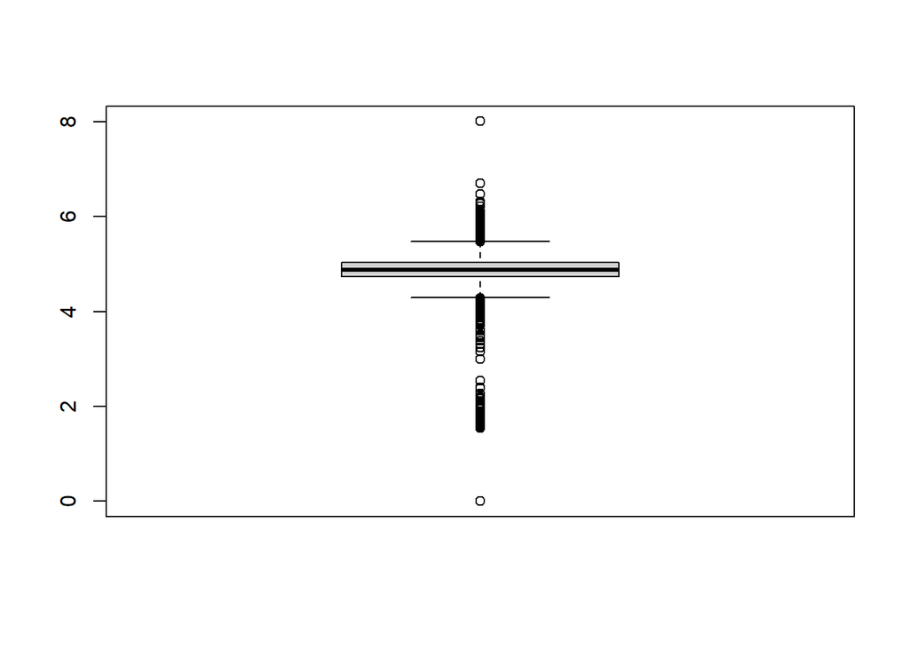

[output not shown]

[output cut: 35 more lines]

```r
boxplot(df$log_income, plot=TRUE)$out
```

## 6.13 Create dataframe without outliers present in log_income

```r
outliers <- boxplot(df$log_income, plot=FALSE)$out
df_1 <- df
df_1 <- df_1[-which(df_1$log_income %in% outliers),]
```

## 6.14 Create boxplot of dataframe without outliers

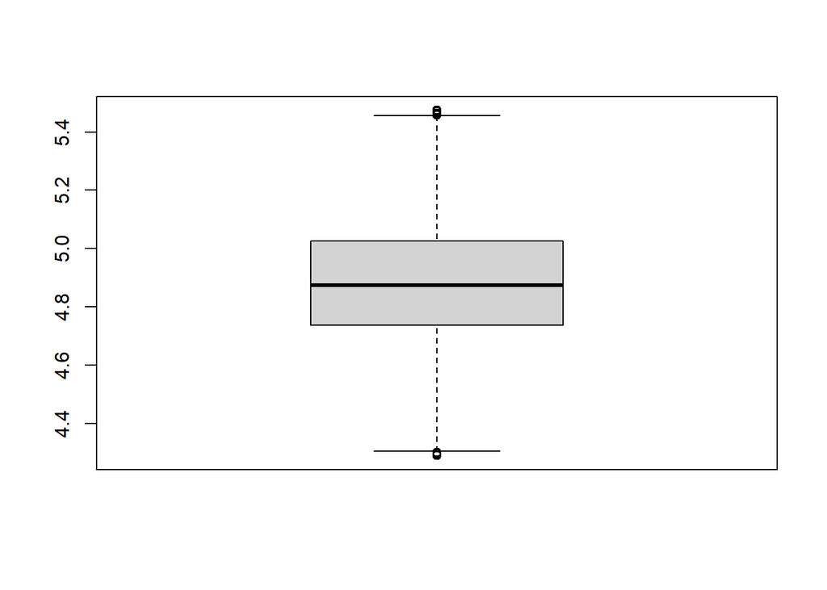

```
##  [1] 4.301030 4.300552 4.301030 5.465383 4.301539 4.301030 4.293952 5.461583
##  [9] 4.290038 4.291879 5.462398 4.294462 4.301030 4.290035 4.301030 4.298526
## [17] 4.301030 5.469822 5.469822 5.457882 4.301030 5.469822 4.301030 5.474046
## [25] 5.457882 4.301030 4.301030 5.457882 4.295787
```

```r
boxplot(df_1$log_income, plot=TRUE)$out
```

## 6.15 Split both dataframes into training and testing sets

```r
dt_1 = sort(sample(nrow(df), nrow(df)*.75))
train_1 <- df[dt_1,]
test_1 <- df[-dt_1,]

dt_2 = sort(sample(nrow(df_1), nrow(df_1)*.75))
train_2 <- df_1[dt_2,]
test_2 <- df_1[-dt_2,]
```

## 6.16 We will create various models with both dataframes

### 6.16.1 First is the dataframe with the aforementioned outliers included

#### 6.16.1.1 This is the model with all the explanatory variables (that have been converted to dummy variables) included

```r
model_lm_1 <- lm(log_income ~
 race_white                                      +   race_asian_white                                +  race_other                                      +
 race_asian_american                             +   race_black_white                                +  race_hispanic                                   +
 race_black                                      +   race_hispanic_white                             +  gender_man                                      +

 gender_woman                                    +   gender_non_binary                               +  gender_other                                    +

 education_high_school                           +   education_some_college                          +  education_college                               +
 education_masters                               +   education_phd                                   +  education_professional                          +

 age_18_24                                       +   age_25_34                                       +  age_35_44                                       +
 age_45_54                                       +   age_55_64                                       +  age_65                                          +

 years_of_experience_in_field_1                  +   years_of_experience_in_field_2_4                +  years_of_experience_in_field_5_7                +
 years_of_experience_in_field_8_10               +   years_of_experience_in_field_11_20              +  years_of_experience_in_field_21_30              +
 years_of_experience_in_field_31_40              +   years_of_experience_in_field_41                 +  overall_years_of_professional_experience_1      +

 overall_years_of_professional_experience_2_4    +   overall_years_of_professional_experience_5_7    +  overall_years_of_professional_experience_8_10   +
 overall_years_of_professional_experience_11_20  +   overall_years_of_professional_experience_21_30  +  overall_years_of_professional_experience_31_40  +
 overall_years_of_professional_experience_41     +

Boston  +
Chicago +
NewYork  +
Seattle +
London +
SanFrancisco +
NewYorkCity +
LosAngeles +
Portland +
Toronto +
Minneapolis  +
Washington +
Austin +
Philadelphia +
Atlanta +
Denver +
WashingtonDC +
Houston +
Pittsburgh +
Vancouver +
Dallas +
Madison +
Columbus +
Baltimore +
Indianapolis +
SanDiego +
Raleigh +
Cleveland +
Phoenix +
Richmond +
Ottawa +
Remote +
Arlington +
Nashville +


 industry_finance             +
 industry_agriculture         +                 industry_art                 +                  industry_business               +
 industry_tech                +                 industry_higher_education    +                  industry_primary_education      +
 industry_engineering         +                 industry_entertainment       +                  industry_government             +
 industry_health              +                 industry_events              +                  industry_insurance              +
 industry_law                 +                 industry_marketing           +                  industry_media                  +
 industry_npo                 +                 industry_property            +                  industry_hr                     +
 industry_retail              +                 industry_sales               +                  industry_social_work            +
 industry_transport           +                 industry_telecom



 , data = train_1)

summary(model_lm_1)
```

```
##
## Call:
## lm(formula = log_income ~ race_white + race_asian_white + race_other +
##     race_asian_american + race_black_white + race_hispanic +
##     race_black + race_hispanic_white + gender_man + gender_woman +
##     gender_non_binary + gender_other + education_high_school +
##     education_some_college + education_college + education_masters +
##     education_phd + education_professional + age_18_24 + age_25_34 +
##     age_35_44 + age_45_54 + age_55_64 + age_65 + years_of_experience_in_field_1 +
##     years_of_experience_in_field_2_4 + years_of_experience_in_field_5_7 +
##     years_of_experience_in_field_8_10 + years_of_experience_in_field_11_20 +
##     years_of_experience_in_field_21_30 + years_of_experience_in_field_31_40 +
##     years_of_experience_in_field_41 + overall_years_of_professional_experience_1 +
##     overall_years_of_professional_experience_2_4 + overall_years_of_professional_experience_5_7 +
##     overall_years_of_professional_experience_8_10 + overall_years_of_professional_experience_11_20 +
##     overall_years_of_professional_experience_21_30 + overall_years_of_professional_experience_31_40 +
##     overall_years_of_professional_experience_41 + Boston + Chicago +
##     NewYork + Seattle + London + SanFrancisco + NewYorkCity +
##     LosAngeles + Portland + Toronto + Minneapolis + Washington +
##     Austin + Philadelphia + Atlanta + Denver + WashingtonDC +
##     Houston + Pittsburgh + Vancouver + Dallas + Madison + Columbus +
##     Baltimore + Indianapolis + SanDiego + Raleigh + Cleveland +
##     Phoenix + Richmond + Ottawa + Remote + Arlington + Nashville +
##     industry_finance + industry_agriculture + industry_art +
##     industry_business + industry_tech + industry_higher_education +
##     industry_primary_education + industry_engineering + industry_entertainment +
##     industry_government + industry_health + industry_events +
##     industry_insurance + industry_law + industry_marketing +
##     industry_media + industry_npo + industry_property + industry_hr +
##     industry_retail + industry_sales + industry_social_work +
##     industry_transport + industry_telecom, data = train_1)
##
## Residuals:
##     Min      1Q  Median      3Q     Max
## -3.3231 -0.0978  0.0076  0.1101  1.7528
##
## Coefficients: (3 not defined because of singularities)
##                                                  Estimate Std. Error t value
## (Intercept)                                     5.0890737  0.2593004  19.626
## race_white                                      0.0067033  0.0128167   0.523
```

[output cut: 189 more lines]

```
## industry_npo                                   4.85e-05 ***
## industry_property                              0.125405
## industry_hr                                    6.37e-06 ***
## industry_retail                                2.38e-08 ***
## industry_sales                                 0.007244 **
## industry_social_work                           1.20e-05 ***
## industry_transport                             0.002682 **
## industry_telecom                               2.43e-07 ***
## ---
## Signif. codes:  0 '***' 0.001 '**' 0.01 '*' 0.05 '.' 0.1 ' ' 1
##
## Residual standard error: 0.2303 on 19400 degrees of freedom
##   (19 observations deleted due to missingness)
## Multiple R-squared:  0.2932, Adjusted R-squared:  0.2897
## F-statistic:  84.7 on 95 and 19400 DF,  p-value: < 2.2e-16
```

#### 6.16.1.2 Collinearity

```r
# Check for perfect collinearity in explanatory variables
alias(model_lm_1)
```

```
## Model :
## log_income ~ race_white + race_asian_white + race_other + race_asian_american +
##     race_black_white + race_hispanic + race_black + race_hispanic_white +
##     gender_man + gender_woman + gender_non_binary + gender_other +
##     education_high_school + education_some_college + education_college +
##     education_masters + education_phd + education_professional +
##     age_18_24 + age_25_34 + age_35_44 + age_45_54 + age_55_64 +
##     age_65 + years_of_experience_in_field_1 + years_of_experience_in_field_2_4 +
##     years_of_experience_in_field_5_7 + years_of_experience_in_field_8_10 +
##     years_of_experience_in_field_11_20 + years_of_experience_in_field_21_30 +
##     years_of_experience_in_field_31_40 + years_of_experience_in_field_41 +
##     overall_years_of_professional_experience_1 + overall_years_of_professional_experience_2_4 +
##     overall_years_of_professional_experience_5_7 + overall_years_of_professional_experience_8_10 +
##     overall_years_of_professional_experience_11_20 + overall_years_of_professional_experience_21_30 +
##     overall_years_of_professional_experience_31_40 + overall_years_of_professional_experience_41 +
##     Boston + Chicago + NewYork + Seattle + London + SanFrancisco +
##     NewYorkCity + LosAngeles + Portland + Toronto + Minneapolis +
##     Washington + Austin + Philadelphia + Atlanta + Denver + WashingtonDC +
##     Houston + Pittsburgh + Vancouver + Dallas + Madison + Columbus +
##     Baltimore + Indianapolis + SanDiego + Raleigh + Cleveland +
##     Phoenix + Richmond + Ottawa + Remote + Arlington + Nashville +
##     industry_finance + industry_agriculture + industry_art +
##     industry_business + industry_tech + industry_higher_education +
##     industry_primary_education + industry_engineering + industry_entertainment +
##     industry_government + industry_health + industry_events +
##     industry_insurance + industry_law + industry_marketing +
##     industry_media + industry_npo + industry_property + industry_hr +
##     industry_retail + industry_sales + industry_social_work +
##     industry_transport + industry_telecom
##
## Complete :
##                                             (Intercept) race_white
## education_professional                       1           0
## years_of_experience_in_field_41              1           0
## overall_years_of_professional_experience_41  1           0
##                                             race_asian_white race_other
## education_professional                       0                0
## years_of_experience_in_field_41              0                0
## overall_years_of_professional_experience_41  0                0
##                                             race_asian_american
```

[output cut: 184 more lines]

```
## education_professional                       0                 0
## years_of_experience_in_field_41              0                 0
## overall_years_of_professional_experience_41  0                 0
##                                             industry_retail industry_sales
## education_professional                       0               0
## years_of_experience_in_field_41              0               0
## overall_years_of_professional_experience_41  0               0
##                                             industry_social_work
## education_professional                       0
## years_of_experience_in_field_41              0
## overall_years_of_professional_experience_41  0
##                                             industry_transport industry_telecom
## education_professional                       0                  0
## years_of_experience_in_field_41              0                  0
## overall_years_of_professional_experience_41  0                  0
```

#### 6.16.1.3 Variance Inflation Factor (will not work if there is perfect collinearity between explanatory variables)

```r
# car::vif(model_lm_1)
```

#### 6.16.1.4 AIC & BIC for model evaluation

```r
AIC_1 <- AIC(model_lm_1, k = 99)
BIC_1 <- BIC(model_lm_1)
```

#### 6.16.1.5 Evaluate Model Prediction

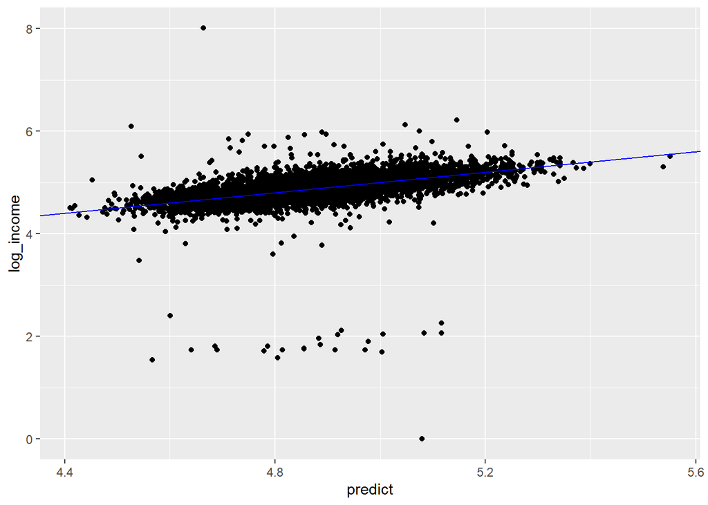

```r
p_1 <- predict.lm(model_lm_1, test_1)

test_1a <- test_1

test_1a$predict <- p_1

ggplot(test_1a, aes(x = predict, y = log_income))+
    geom_point() +
    geom_abline(color = "blue")
```

#### 6.16.1.6 Calculate RMSE for model

```r
n <- nrow(test_1a)

diff <- test_1a$predict - test_1a$log_income

squared_diff <- diff^2

sum_diff <- sum(squared_diff, na.rm = TRUE)

RMSE_1 <- sqrt(sum_diff/n)

RMSE_1
```

```
## [1] 0.2613226
```

### 6.16.2 Second is the optimal model we have found given the baseline model above

```r
model_lm_2 <- lm(log_income ~ race_white +  race_asian_american     +   gender_man      +
 education_high_school       +                   education_some_college   +                      education_college     +
 education_masters           +                   education_phd            +
 years_of_experience_in_field_1 +                years_of_experience_in_field_2_4 +              years_of_experience_in_field_5_7 +
 years_of_experience_in_field_8_10  +            years_of_experience_in_field_11_20 +
 overall_years_of_professional_experience_31_40 +

Boston  +
Chicago +
NewYork  +
Seattle +
London +
SanFrancisco +
NewYorkCity +
LosAngeles +
Portland +
Toronto +
Minneapolis  +
Washington +
Austin +
Philadelphia +
Atlanta +
Denver +
WashingtonDC +
Houston +
Vancouver +
Dallas +
Baltimore +
SanDiego +
Raleigh +
Remote +
Arlington +

industry_finance    +
industry_agriculture  +                         industry_art                 +                  industry_business               +
industry_tech          +                        industry_higher_education   +                   industry_primary_education       +
industry_engineering    +                       industry_government               +
industry_events        +                        industry_media                      +           industry_npo               +
industry_property    +                          industry_retail             +                   industry_sales      +                           industry_social_work


 , data = train_1)

summary(model_lm_2)
```

```
##
## Call:
## lm(formula = log_income ~ race_white + race_asian_american +
##     gender_man + education_high_school + education_some_college +
##     education_college + education_masters + education_phd + years_of_experience_in_field_1 +
##     years_of_experience_in_field_2_4 + years_of_experience_in_field_5_7 +
##     years_of_experience_in_field_8_10 + years_of_experience_in_field_11_20 +
##     overall_years_of_professional_experience_31_40 + Boston +
##     Chicago + NewYork + Seattle + London + SanFrancisco + NewYorkCity +
##     LosAngeles + Portland + Toronto + Minneapolis + Washington +
##     Austin + Philadelphia + Atlanta + Denver + WashingtonDC +
##     Houston + Vancouver + Dallas + Baltimore + SanDiego + Raleigh +
##     Remote + Arlington + industry_finance + industry_agriculture +
##     industry_art + industry_business + industry_tech + industry_higher_education +
##     industry_primary_education + industry_engineering + industry_government +
##     industry_events + industry_media + industry_npo + industry_property +
##     industry_retail + industry_sales + industry_social_work,
##     data = train_1)
##
## Residuals:
##     Min      1Q  Median      3Q     Max
## -3.3398 -0.0984  0.0081  0.1121  1.7347
##
## Coefficients:
##                                                 Estimate Std. Error t value
## (Intercept)                                     5.139449   0.011096 463.189
## race_white                                     -0.010597   0.005314  -1.994
## race_asian_american                             0.048177   0.009257   5.204
## gender_man                                      0.043815   0.004537   9.658
## education_high_school                          -0.291549   0.013761 -21.186
## education_some_college                         -0.287411   0.009973 -28.819
## education_college                              -0.200847   0.008051 -24.948
## education_masters                              -0.155948   0.008252 -18.899
## education_phd                                  -0.056375   0.010724  -5.257
## years_of_experience_in_field_1                 -0.288148   0.009882 -29.160
## years_of_experience_in_field_2_4               -0.224378   0.007269 -30.866
## years_of_experience_in_field_5_7               -0.152983   0.007186 -21.290
## years_of_experience_in_field_8_10              -0.096923   0.007417 -13.067
## years_of_experience_in_field_11_20             -0.049012   0.007074  -6.928
## overall_years_of_professional_experience_31_40 -0.024039   0.010366  -2.319
```

[output cut: 90 more lines]

```
## industry_government                            0.049739 *
## industry_events                                1.50e-06 ***
## industry_media                                 0.001039 **
## industry_npo                                    < 2e-16 ***
## industry_property                              0.360749
## industry_retail                                 < 2e-16 ***
## industry_sales                                 0.776034
## industry_social_work                           1.06e-12 ***
## ---
## Signif. codes:  0 '***' 0.001 '**' 0.01 '*' 0.05 '.' 0.1 ' ' 1
##
## Residual standard error: 0.2315 on 19440 degrees of freedom
##   (19 observations deleted due to missingness)
## Multiple R-squared:  0.2842, Adjusted R-squared:  0.2821
## F-statistic: 140.3 on 55 and 19440 DF,  p-value: < 2.2e-16
```

#### 6.16.2.1 Collinearity

```r
# Check for perfect collinearity in explanatory variables
alias(model_lm_2)
```

```
## Model :
## log_income ~ race_white + race_asian_american + gender_man +
##     education_high_school + education_some_college + education_college +
##     education_masters + education_phd + years_of_experience_in_field_1 +
##     years_of_experience_in_field_2_4 + years_of_experience_in_field_5_7 +
##     years_of_experience_in_field_8_10 + years_of_experience_in_field_11_20 +
##     overall_years_of_professional_experience_31_40 + Boston +
##     Chicago + NewYork + Seattle + London + SanFrancisco + NewYorkCity +
##     LosAngeles + Portland + Toronto + Minneapolis + Washington +
##     Austin + Philadelphia + Atlanta + Denver + WashingtonDC +
##     Houston + Vancouver + Dallas + Baltimore + SanDiego + Raleigh +
##     Remote + Arlington + industry_finance + industry_agriculture +
##     industry_art + industry_business + industry_tech + industry_higher_education +
##     industry_primary_education + industry_engineering + industry_government +
##     industry_events + industry_media + industry_npo + industry_property +
##     industry_retail + industry_sales + industry_social_work
```

#### 6.16.2.2 Variance Inflation Factor (will not work if there is perfect collinearity between explanatory variables)

```r
car::vif(model_lm_2)
```

```
##                                     race_white
##                                       1.368769
##                            race_asian_american
##                                       1.364045
##                                     gender_man
##                                       1.113993
##                          education_high_school
##                                       1.459067
##                         education_some_college
##                                       2.372227
##                              education_college
##                                       5.887952
##                              education_masters
##                                       5.429925
##                                  education_phd
##                                       2.065039
##                 years_of_experience_in_field_1
##                                       1.640195
##               years_of_experience_in_field_2_4
##                                       3.284886
##               years_of_experience_in_field_5_7
##                                       3.341685
##              years_of_experience_in_field_8_10
##                                       2.947148
##             years_of_experience_in_field_11_20
##                                       3.296206
## overall_years_of_professional_experience_31_40
##                                       1.188617
##                                         Boston
##                                       1.023627
##                                        Chicago
##                                       1.021781
##                                        NewYork
##                                       1.041888
##                                        Seattle
##                                       1.027126
##                                         London
##                                       1.020611
##                                   SanFrancisco
##                                       1.039773
```

[output cut: 55 more lines]

```
##                                       1.186258
##                                industry_events
##                                       1.029394
##                                 industry_media
##                                       1.094800
##                                   industry_npo
##                                       1.232918
##                              industry_property
##                                       1.040165
##                                industry_retail
##                                       1.059539
##                                 industry_sales
##                                       1.031489
##                           industry_social_work
##                                       1.037895
```

#### 6.16.2.3 AIC & BIC for model evaluation

```r
AIC_2 <- AIC(model_lm_2, k = 52)
BIC_2 <- BIC(model_lm_2)
```

#### 6.16.2.4 Evaluate Model Prediction

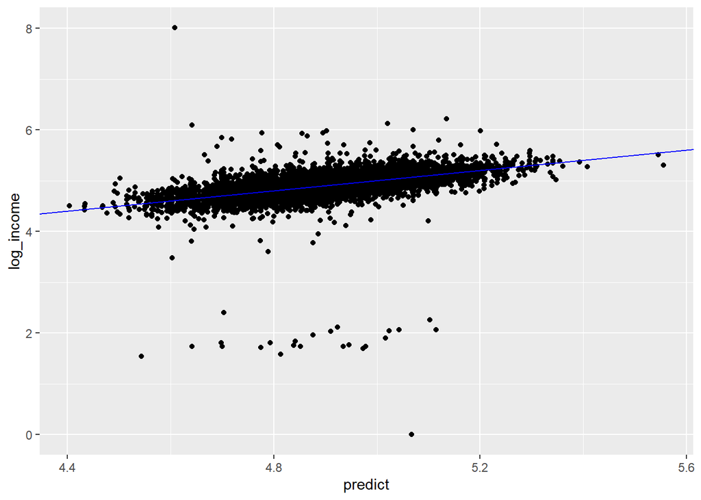

```r
p_2 <- predict.lm(model_lm_2, test_1)

test_1b <- test_1

test_1b$predict <- p_2

ggplot(test_1b, aes(x = predict, y = log_income))+
    geom_point() +
    geom_abline(color = "blue")
```

#### 6.16.2.5 Calculate RMSE for model

```r
n_2 <- nrow(test_1b)

diff_2 <- test_1b$predict - test_1b$log_income

squared_diff_2 <- diff_2^2

sum_diff_2 <- sum(squared_diff_2, na.rm = TRUE)

RMSE_2 <- sqrt(sum_diff_2/n_2)

RMSE_2
```

```
## [1] 0.2620364
```

### 6.16.3 Next is the dataframe with the aforementioned outliers excluded

#### 6.16.3.1 This is the model with all the explanatory variables (that have been converted to dummy variables) included

```r
model_lm_3 <- lm(log_income ~ race_white + race_asian_white  + race_other   +
 race_asian_american                             +   race_black_white                                +  race_hispanic                                   +
 race_black                                      +   race_hispanic_white                             +  gender_man                                      +

 gender_woman                                    +   gender_non_binary                               +  gender_other                                    +

 education_high_school                           +   education_some_college                          +  education_college                               +
 education_masters                               +   education_phd                                   +  education_professional                          +

 age_18_24                                       +   age_25_34                                       +  age_35_44                                       +
 age_45_54                                       +   age_55_64                                       +  age_65                                          +

 years_of_experience_in_field_1                  +   years_of_experience_in_field_2_4                +  years_of_experience_in_field_5_7                +
 years_of_experience_in_field_8_10               +   years_of_experience_in_field_11_20              +  years_of_experience_in_field_21_30              +
 years_of_experience_in_field_31_40              +   years_of_experience_in_field_41                 +  overall_years_of_professional_experience_1      +

 overall_years_of_professional_experience_2_4    +   overall_years_of_professional_experience_5_7    +  overall_years_of_professional_experience_8_10   +
 overall_years_of_professional_experience_11_20  +   overall_years_of_professional_experience_21_30  +  overall_years_of_professional_experience_31_40  +
 overall_years_of_professional_experience_41     +

 Boston  +
 Chicago +
 NewYork  +
 Seattle +
 London +
 SanFrancisco +
 NewYorkCity +
 LosAngeles +
 Portland +
 Toronto +
 Minneapolis  +
 Washington +
 Austin +
 Philadelphia +
 Atlanta +
 Denver +
 WashingtonDC +
 Houston +
 Pittsburgh +
 Vancouver +
 Dallas +
 Madison +
 Columbus +
 Baltimore +
 Indianapolis +
 SanDiego +
 Raleigh +
 Cleveland +
 Phoenix +
 Richmond +
 Ottawa +
 Remote +
 Arlington +
 Nashville +

 industry_finance             +
 industry_agriculture         +                 industry_art                 +                  industry_business               +
 industry_tech                +                 industry_higher_education    +                  industry_primary_education      +
 industry_engineering         +                 industry_entertainment       +                  industry_government             +
 industry_health              +                 industry_events              +                  industry_insurance              +
 industry_law                 +                 industry_marketing           +                  industry_media                  +
 industry_npo                 +                 industry_property            +                  industry_hr                     +
 industry_retail              +                 industry_sales               +                  industry_social_work            +
 industry_transport           +                 industry_telecom



 , data = train_2)

summary(model_lm_3)
```

```
##
## Call:
## lm(formula = log_income ~ race_white + race_asian_white + race_other +
##     race_asian_american + race_black_white + race_hispanic +
##     race_black + race_hispanic_white + gender_man + gender_woman +
##     gender_non_binary + gender_other + education_high_school +
##     education_some_college + education_college + education_masters +
##     education_phd + education_professional + age_18_24 + age_25_34 +
##     age_35_44 + age_45_54 + age_55_64 + age_65 + years_of_experience_in_field_1 +
##     years_of_experience_in_field_2_4 + years_of_experience_in_field_5_7 +
##     years_of_experience_in_field_8_10 + years_of_experience_in_field_11_20 +
##     years_of_experience_in_field_21_30 + years_of_experience_in_field_31_40 +
##     years_of_experience_in_field_41 + overall_years_of_professional_experience_1 +
##     overall_years_of_professional_experience_2_4 + overall_years_of_professional_experience_5_7 +
##     overall_years_of_professional_experience_8_10 + overall_years_of_professional_experience_11_20 +
##     overall_years_of_professional_experience_21_30 + overall_years_of_professional_experience_31_40 +
##     overall_years_of_professional_experience_41 + Boston + Chicago +
##     NewYork + Seattle + London + SanFrancisco + NewYorkCity +
##     LosAngeles + Portland + Toronto + Minneapolis + Washington +
##     Austin + Philadelphia + Atlanta + Denver + WashingtonDC +
##     Houston + Pittsburgh + Vancouver + Dallas + Madison + Columbus +
##     Baltimore + Indianapolis + SanDiego + Raleigh + Cleveland +
##     Phoenix + Richmond + Ottawa + Remote + Arlington + Nashville +
##     industry_finance + industry_agriculture + industry_art +
##     industry_business + industry_tech + industry_higher_education +
##     industry_primary_education + industry_engineering + industry_entertainment +
##     industry_government + industry_health + industry_events +
##     industry_insurance + industry_law + industry_marketing +
##     industry_media + industry_npo + industry_property + industry_hr +
##     industry_retail + industry_sales + industry_social_work +
##     industry_transport + industry_telecom, data = train_2)
##
## Residuals:
##      Min       1Q   Median       3Q      Max
## -0.68630 -0.10310  0.00001  0.10105  0.83722
##
## Coefficients: (4 not defined because of singularities)
##                                                  Estimate Std. Error t value
## (Intercept)                                     5.1510945  0.0790898  65.130
## race_white                                     -0.0029847  0.0086968  -0.343
```

[output cut: 189 more lines]

```
## industry_npo                                   1.15e-11 ***
## industry_property                              0.119386
## industry_hr                                    6.55e-07 ***
## industry_retail                                5.14e-10 ***
## industry_sales                                 0.066535 .
## industry_social_work                           6.27e-09 ***
## industry_transport                             0.002624 **
## industry_telecom                               2.52e-13 ***
## ---
## Signif. codes:  0 '***' 0.001 '**' 0.01 '*' 0.05 '.' 0.1 ' ' 1
##
## Residual standard error: 0.1558 on 19099 degrees of freedom
##   (21 observations deleted due to missingness)
## Multiple R-squared:  0.4475, Adjusted R-squared:  0.4448
## F-statistic: 164.6 on 94 and 19099 DF,  p-value: < 2.2e-16
```

#### 6.16.3.2 Collinearity

```r
# Check for perfect collinearity in explanatory variables
alias(model_lm_3)
```

```
## Model :
## log_income ~ race_white + race_asian_white + race_other + race_asian_american +
##     race_black_white + race_hispanic + race_black + race_hispanic_white +
##     gender_man + gender_woman + gender_non_binary + gender_other +
##     education_high_school + education_some_college + education_college +
##     education_masters + education_phd + education_professional +
##     age_18_24 + age_25_34 + age_35_44 + age_45_54 + age_55_64 +
##     age_65 + years_of_experience_in_field_1 + years_of_experience_in_field_2_4 +
##     years_of_experience_in_field_5_7 + years_of_experience_in_field_8_10 +
##     years_of_experience_in_field_11_20 + years_of_experience_in_field_21_30 +
##     years_of_experience_in_field_31_40 + years_of_experience_in_field_41 +
##     overall_years_of_professional_experience_1 + overall_years_of_professional_experience_2_4 +
##     overall_years_of_professional_experience_5_7 + overall_years_of_professional_experience_8_10 +
##     overall_years_of_professional_experience_11_20 + overall_years_of_professional_experience_21_30 +
##     overall_years_of_professional_experience_31_40 + overall_years_of_professional_experience_41 +
##     Boston + Chicago + NewYork + Seattle + London + SanFrancisco +
##     NewYorkCity + LosAngeles + Portland + Toronto + Minneapolis +
##     Washington + Austin + Philadelphia + Atlanta + Denver + WashingtonDC +
##     Houston + Pittsburgh + Vancouver + Dallas + Madison + Columbus +
##     Baltimore + Indianapolis + SanDiego + Raleigh + Cleveland +
##     Phoenix + Richmond + Ottawa + Remote + Arlington + Nashville +
##     industry_finance + industry_agriculture + industry_art +
##     industry_business + industry_tech + industry_higher_education +
##     industry_primary_education + industry_engineering + industry_entertainment +
##     industry_government + industry_health + industry_events +
##     industry_insurance + industry_law + industry_marketing +
##     industry_media + industry_npo + industry_property + industry_hr +
##     industry_retail + industry_sales + industry_social_work +
##     industry_transport + industry_telecom
##
## Complete :
##                                             (Intercept) race_white
## gender_other                                 1           0
## education_professional                       1           0
## years_of_experience_in_field_41              1           0
## overall_years_of_professional_experience_41  1           0
##                                             race_asian_white race_other
## gender_other                                 0                0
## education_professional                       0                0
## years_of_experience_in_field_41              0                0
```

[output cut: 236 more lines]

```
##                                             industry_retail industry_sales
## gender_other                                 0               0
## education_professional                       0               0
## years_of_experience_in_field_41              0               0
## overall_years_of_professional_experience_41  0               0
##                                             industry_social_work
## gender_other                                 0
## education_professional                       0
## years_of_experience_in_field_41              0
## overall_years_of_professional_experience_41  0
##                                             industry_transport industry_telecom
## gender_other                                 0                  0
## education_professional                       0                  0
## years_of_experience_in_field_41              0                  0
## overall_years_of_professional_experience_41  0                  0
```

#### 6.16.3.3 Variance Inflation Factor

```r
# car::vif(model_lm_3)
```

#### 6.16.3.4 AIC & BIC for model evaluation

```r
AIC_3 <- AIC(model_lm_3, k = 100)
BIC_3 <- BIC(model_lm_3)
```

#### 6.16.3.5 Evaluate Model Prediction

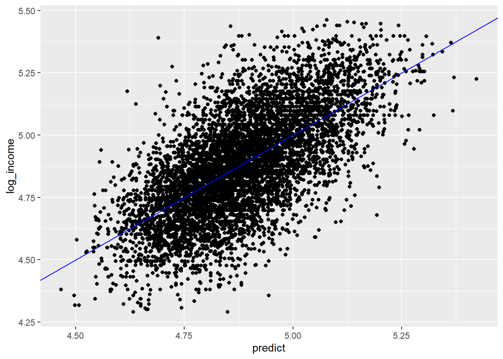

```r
p_3 <- predict.lm(model_lm_3, test_2)

test_2a <- test_2

test_2a$predict <- p_3

ggplot(test_2a, aes(x = predict, y = log_income))+
    geom_point() +
    geom_abline(color = "blue")
```

#### 6.16.3.6 Calculate RMSE for model

```r
n_3 <- nrow(test_2a)

diff_3 <- test_2a$predict - test_2a$log_income

squared_diff_3 <- diff_3^2

sum_diff_3 <- sum(squared_diff_3, na.rm = TRUE)

RMSE_3 <- sqrt(sum_diff_3/n_3)

RMSE_3
```

```
## [1] 0.1562545
```

### 6.16.4 Second is the optimal model we have found given the baseline model above

```r
model_lm_4 <- lm(log_income ~   race_other   +     race_asian_american            +
 race_black                                      +   gender_man                                      +  gender_non_binary                               +
 education_high_school                           +   education_some_college                          +  education_college                               +
 education_masters                               +   education_phd                                   +
 age_18_24                                       +   age_55_64                                       +  years_of_experience_in_field_1                  +
 years_of_experience_in_field_2_4                +   years_of_experience_in_field_5_7                +
 years_of_experience_in_field_8_10               +   years_of_experience_in_field_11_20              +  years_of_experience_in_field_21_30              +
 overall_years_of_professional_experience_1      +   overall_years_of_professional_experience_8_10   +
 overall_years_of_professional_experience_11_20  +   overall_years_of_professional_experience_21_30  +


Boston  +
Chicago +
NewYork  +
Seattle +
SanFrancisco +
NewYorkCity +
LosAngeles +
Portland +
Toronto +
Minneapolis  +
Washington +
Austin +
Philadelphia +
Atlanta +
Denver +
WashingtonDC +
Houston +
Dallas +
Baltimore +
SanDiego +
Ottawa +
Remote +
Arlington +

 industry_art                 +                 industry_business            +
 industry_tech                +                 industry_higher_education    +                  industry_primary_education      +
 industry_engineering         +                 industry_entertainment       +                  industry_government             +
 industry_health              +                 industry_events              +
 industry_law                 +                 industry_media               +
 industry_npo                 +                 industry_property            +
 industry_retail              +                 industry_sales               +                  industry_social_work            +
 industry_transport

 , data = train_2)

summary(model_lm_4)
```

```
##
## Call:
## lm(formula = log_income ~ race_other + race_asian_american +
##     race_black + gender_man + gender_non_binary + education_high_school +
##     education_some_college + education_college + education_masters +
##     education_phd + age_18_24 + age_55_64 + years_of_experience_in_field_1 +
##     years_of_experience_in_field_2_4 + years_of_experience_in_field_5_7 +
##     years_of_experience_in_field_8_10 + years_of_experience_in_field_11_20 +
##     years_of_experience_in_field_21_30 + overall_years_of_professional_experience_1 +
##     overall_years_of_professional_experience_8_10 + overall_years_of_professional_experience_11_20 +
##     overall_years_of_professional_experience_21_30 + Boston +
##     Chicago + NewYork + Seattle + SanFrancisco + NewYorkCity +
##     LosAngeles + Portland + Toronto + Minneapolis + Washington +
##     Austin + Philadelphia + Atlanta + Denver + WashingtonDC +
##     Houston + Dallas + Baltimore + SanDiego + Ottawa + Remote +
##     Arlington + industry_art + industry_business + industry_tech +
##     industry_higher_education + industry_primary_education +
##     industry_engineering + industry_entertainment + industry_government +
##     industry_health + industry_events + industry_law + industry_media +
##     industry_npo + industry_property + industry_retail + industry_sales +
##     industry_social_work + industry_transport, data = train_2)
##
## Residuals:
##      Min       1Q   Median       3Q      Max
## -0.68707 -0.10309  0.00023  0.10242  0.84891
##
## Coefficients:
##                                                 Estimate Std. Error t value
## (Intercept)                                     5.112718   0.012220 418.403
## race_other                                      0.032802   0.007935   4.134
## race_asian_american                             0.064088   0.005484  11.686
## race_black                                      0.030037   0.007536   3.986
## gender_man                                      0.047039   0.003121  15.071
## gender_non_binary                              -0.038197   0.006983  -5.470
## education_high_school                          -0.267776   0.010052 -26.640
## education_some_college                         -0.253047   0.007417 -34.116
## education_college                              -0.176041   0.006275 -28.055
## education_masters                              -0.132875   0.006381 -20.823
## education_phd                                  -0.039928   0.007919  -5.042
## age_18_24                                      -0.036019   0.006752  -5.335
```

[output cut: 109 more lines]

```
## industry_law                                   0.793135
## industry_media                                 0.000127 ***
## industry_npo                                    < 2e-16 ***
## industry_property                              0.018153 *
## industry_retail                                 < 2e-16 ***
## industry_sales                                 0.078231 .
## industry_social_work                            < 2e-16 ***
## industry_transport                             0.507411
## ---
## Signif. codes:  0 '***' 0.001 '**' 0.01 '*' 0.05 '.' 0.1 ' ' 1
##
## Residual standard error: 0.1567 on 19130 degrees of freedom
##   (21 observations deleted due to missingness)
## Multiple R-squared:  0.4403, Adjusted R-squared:  0.4385
## F-statistic: 238.9 on 63 and 19130 DF,  p-value: < 2.2e-16
```

#### 6.16.4.1 Collinearity

```r
# Check for perfect collinearity in explanatory variables
alias(model_lm_4)
```

```
## Model :
## log_income ~ race_other + race_asian_american + race_black +
##     gender_man + gender_non_binary + education_high_school +
##     education_some_college + education_college + education_masters +
##     education_phd + age_18_24 + age_55_64 + years_of_experience_in_field_1 +
##     years_of_experience_in_field_2_4 + years_of_experience_in_field_5_7 +
##     years_of_experience_in_field_8_10 + years_of_experience_in_field_11_20 +
##     years_of_experience_in_field_21_30 + overall_years_of_professional_experience_1 +
##     overall_years_of_professional_experience_8_10 + overall_years_of_professional_experience_11_20 +
##     overall_years_of_professional_experience_21_30 + Boston +
##     Chicago + NewYork + Seattle + SanFrancisco + NewYorkCity +
##     LosAngeles + Portland + Toronto + Minneapolis + Washington +
##     Austin + Philadelphia + Atlanta + Denver + WashingtonDC +
##     Houston + Dallas + Baltimore + SanDiego + Ottawa + Remote +
##     Arlington + industry_art + industry_business + industry_tech +
##     industry_higher_education + industry_primary_education +
##     industry_engineering + industry_entertainment + industry_government +
##     industry_health + industry_events + industry_law + industry_media +
##     industry_npo + industry_property + industry_retail + industry_sales +
##     industry_social_work + industry_transport
```

#### 6.16.4.2 Variance Inflation Factor (will not work if there is perfect collinearity between explanatory variables)

```r
car::vif(model_lm_4)
```

```
##                                     race_other
##                                       1.006917
##                            race_asian_american
##                                       1.043225
##                                     race_black
##                                       1.016595
##                                     gender_man
##                                       1.126326
##                              gender_non_binary
##                                       1.021701
##                          education_high_school
##                                       1.580418
##                         education_some_college
##                                       2.870349
##                              education_college
##                                       7.690528
##                              education_masters
##                                       6.959592
##                                  education_phd
##                                       2.380058
##                                      age_18_24
##                                       1.278252
##                                      age_55_64
##                                       1.352333
##                 years_of_experience_in_field_1
##                                       5.145375
##               years_of_experience_in_field_2_4
##                                      15.117197
##               years_of_experience_in_field_5_7
##                                      15.677415
##              years_of_experience_in_field_8_10
##                                      13.357739
##             years_of_experience_in_field_11_20
##                                      16.440473
##             years_of_experience_in_field_21_30
##                                       6.246438
##     overall_years_of_professional_experience_1
##                                       1.465953
##  overall_years_of_professional_experience_8_10
##                                       1.709042
```

[output cut: 71 more lines]

```
##                                       1.440248
##                                 industry_media
##                                       1.104498
##                                   industry_npo
##                                       1.287086
##                              industry_property
##                                       1.048780
##                                industry_retail
##                                       1.065091
##                                 industry_sales
##                                       1.034539
##                           industry_social_work
##                                       1.046390
##                             industry_transport
##                                       1.040146
```

#### 6.16.4.3 AIC & BIC for model evaluation

```r
AIC_4 <- AIC(model_lm_4, k = 53)
BIC_4 <- BIC(model_lm_4)
```

#### 6.16.4.4 Evaluate Model Prediction

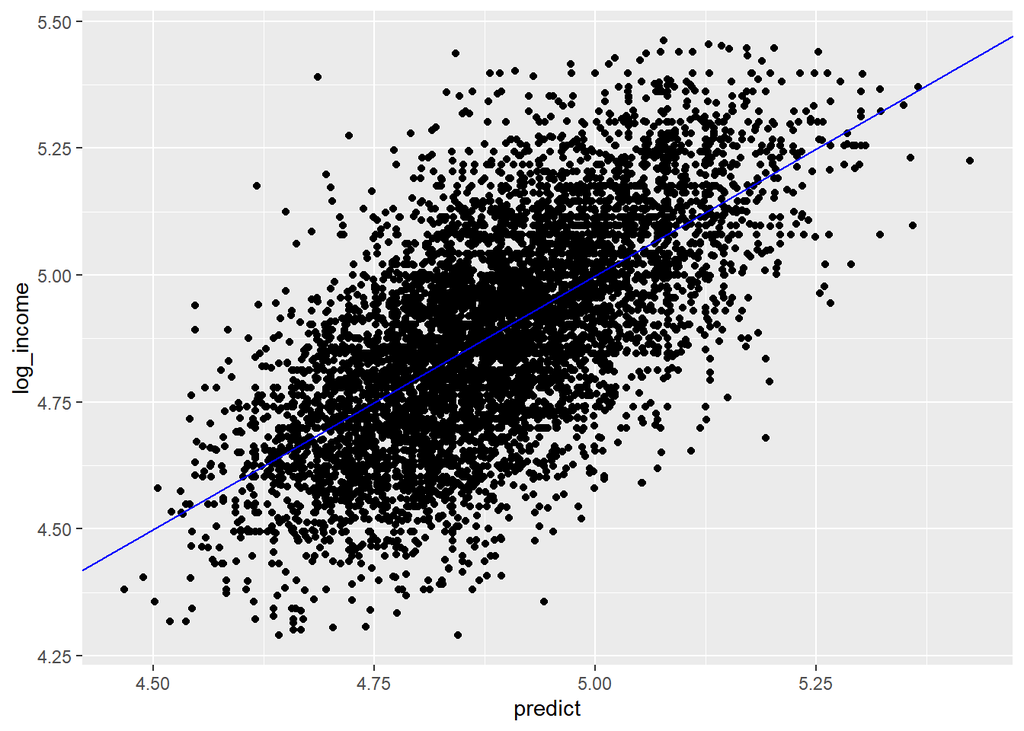

```r
p_4 <- predict.lm(model_lm_4, test_2)

test_2b <- test_2

test_2b$predict <- p_4

ggplot(test_2b, aes(x = predict, y = log_income))+
    geom_point() +
    geom_abline(color = "blue")
```

#### 6.16.4.5 Calculate RMSE for model

```r
n_4 <- nrow(test_2b)

diff_4 <- test_2b$predict - test_2b$log_income

squared_diff_4 <- diff_4^2

sum_diff_4 <- sum(squared_diff_4, na.rm = TRUE)

RMSE_4 <- sqrt(sum_diff_4/n_4)

RMSE_4
```

```
## [1] 0.156756
```

#### 6.16.4.6 Model Comparison with AIC (the model with the lowest score is the preferred model)

```r
AIC_1
```

```
## [1] 7572.073
```

```r
AIC_2
```

```
## [1] 1180.342
```

```r
AIC_3
```

```
## [1] -7394.827
```

```r
AIC_4
```

```
## [1] -13303.16
```

#### 6.16.4.7 Model Comparison with BIC (the model with the lowest score is the preferred model)

```r
BIC_1
```

```
## [1] -1072.764
```

```r
BIC_2
```

```
## [1] -1220.614
```

```r
BIC_3
```

```
## [1] -16048.04
```

```r
BIC_4
```

```
## [1] -16107.11
```

#### 6.16.4.8 Model Comparison with RMSE (the model with the lowest value is the preferred model)

```r
RMSE_1
```

```
## [1] 0.2613226
```

```r
RMSE_2
```

```
## [1] 0.2620364
```

```r
RMSE_3
```

```
## [1] 0.1562545
```

```r
RMSE_4
```

```
## [1] 0.156756
```